# HELPS-vignette

```r
library(HELPS)
library(ncdf4)
library(raster)
library(dplyr)
```

```r
library(ggplot2)
library(knitr)
library(sf)
```

## Obtain example data:

```r
get_example_data()
```

## 1. Daily gridded inputs:

### Step1.1: calculate daily gridded heat stress

```r
wbgt.sun.day <- HeatStress(TempRes = "day", SECTOR = "MAIZ_R", HS = WBGT_sun, YEAR_INPUT = 2024,
                    "../HELPS_Example_Data/hurs_example_day.nc",
                    "../HELPS_Example_Data/tas_example_day.nc",
                    "../HELPS_Example_Data/ps_example_day.nc")
```

```
#> |---------|---------|---------|---------|=========================================                                          |---------|---------|---------|---------|=========================================
```

```r
wbgt.sun.day
```

```
#> class      : RasterStack
#> dimensions : 360, 720, 259200, 366  (nrow, ncol, ncell, nlayers)
#> resolution : 0.5, 0.5  (x, y)
#> extent     : -180, 180, -90, 90  (xmin, xmax, ymin, ymax)
#> crs        : +proj=longlat +datum=WGS84 +no_defs
#> names      :  X2024.01.01,  X2024.01.02,  X2024.01.03,  X2024.01.04,  X2024.01.05,  X2024.01.06,  X2024.01.07,  X2024.01.08,  X2024.01.09,  X2024.01.10,  X2024.01.11,  X2024.01.12,  X2024.01.13,  X2024.01.14,  X2024.01.15, ...
#> min values : -26.40895633, -29.58631649, -29.48563671, -32.64279411, -32.68470744, -31.52423488, -30.81504258, -31.72978783, -32.97928824, -31.53499160, -30.23718614, -26.68727971, -27.45448612, -30.39889939, -29.37254204, ...
#> max values :     33.69000,     33.01880,     32.68530,     33.07450,     32.27624,     32.50649,     32.55792,     32.97666,     33.03015,     33.14957,     33.11487,     32.81420,     32.97180,     32.96513,     32.74074, ...
```

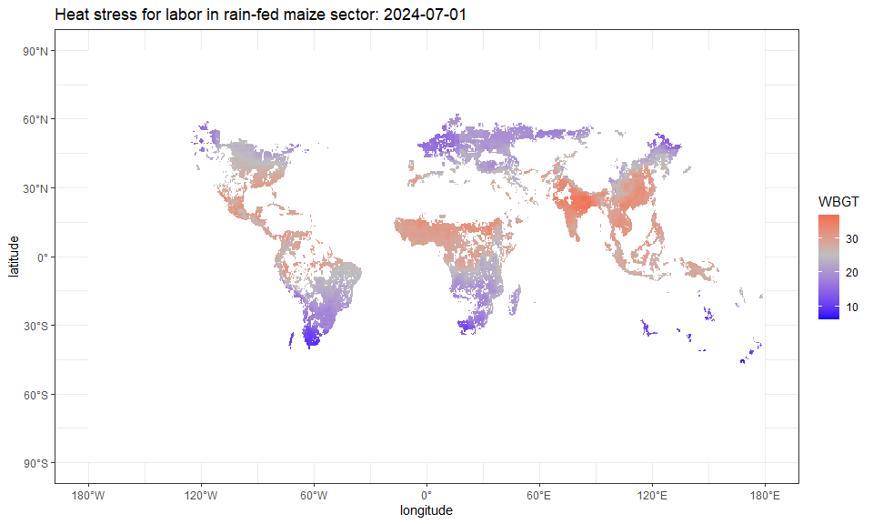

```r
wbgt.day.plot <- wbgt.sun.day[[183]] %>% as.data.frame(xy = T)

format_longitude <- function(lon) {
  sapply(lon, function(x) {
    if (x > 0) paste0(x, "°E")
    else if (x < 0) paste0(abs(x), "°W")
    else paste0(x, "°") # Handle 0° specifically
  })
}

format_latitude <- function(lat) {
  sapply(lat, function(x) {
    if (x > 0) paste0(x, "°N")
    else if (x < 0) paste0(abs(x), "°S")
    else paste0(x, "°") # Handle 0° specifically
  })
}
wbgt.day.plot %>%
  setNames(c("x", "y", "value")) %>%
  ggplot() +
  geom_tile(aes(x = x, y = y, fill = value)) +
  scale_fill_gradient2(low = "blue", mid = "grey", high = "red", midpoint = 25,
                       na.value = "white")+
  labs(x = "longitude", y = "latitude", fill = "WBGT",
       title = "Heat stress for labor in rain-fed maize sector: 2024-07-01") +

  scale_x_continuous(
    breaks = seq(-180, 180, by = 60), # Longitude breaks
    labels = format_longitude         # Apply custom labels
  ) +
  scale_y_continuous(
    breaks = seq(-90, 90, by = 30),    # Latitude breaks
    labels = format_latitude           # Apply custom latitude labels
  ) +
  theme_bw()
```

### Step1.2: calculate daily gridded physical work capacity

This step employs `PWC()` function, which takes multiple arguments. `WBGT` denotes the output of `HeatStress()` from last step. `LHR` denotes the labor-heat response function that takes heat stress level and workload intensity as input and outputs physical work capacity (PWC). `workload` varies across alternative industries, we suggest ‘high’ for construction or agricultural work, ‘moderate’ for average manufacturing industry work, and ‘low’ for office desk work and service industries.

```r
pwc.hothaps.day <- PWC(WBGT = wbgt.sun.day,  LHR = LHR_Hothaps, workload = "high")
pwc.hothaps.day
```

```
#> class      : RasterStack
#> dimensions : 360, 720, 259200, 366  (nrow, ncol, ncell, nlayers)
#> resolution : 0.5, 0.5  (x, y)
#> extent     : -180, 180, -90, 90  (xmin, xmax, ymin, ymax)
#> crs        : +proj=longlat +datum=WGS84 +no_defs
#> names      : X2024.01.01, X2024.01.02, X2024.01.03, X2024.01.04, X2024.01.05, X2024.01.06, X2024.01.07, X2024.01.08, X2024.01.09, X2024.01.10, X2024.01.11, X2024.01.12, X2024.01.13, X2024.01.14, X2024.01.15, ...
#> min values :   0.2756310,   0.3278060,   0.3577239,   0.3230669,   0.3979197,   0.3748341,   0.3698383,   0.3314406,   0.3268341,   0.3167981,   0.3196790,   0.3458487,   0.3318618,   0.3324419,   0.3525687, ...
#> max values :           1,           1,           1,           1,           1,           1,           1,           1,           1,           1,           1,           1,           1,           1,           1, ...
```

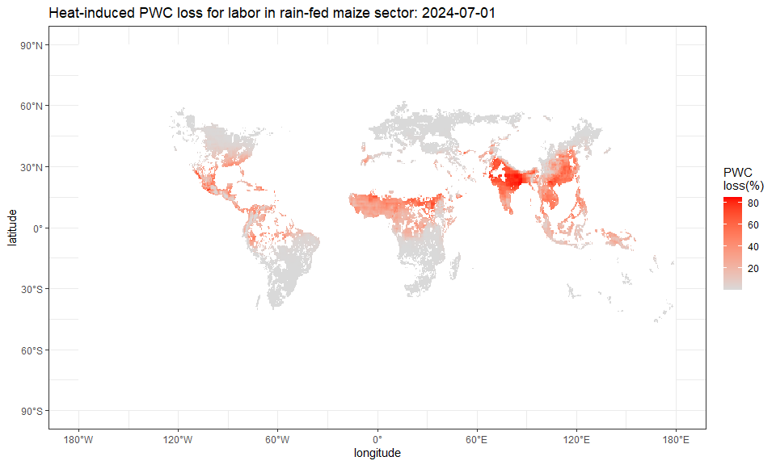

```r
pwc.day.plot <- pwc.hothaps.day[[183]] %>% as.data.frame(xy = T)

format_longitude <- function(lon) {
  sapply(lon, function(x) {
    if (x > 0) paste0(x, "°E")
    else if (x < 0) paste0(abs(x), "°W")
    else paste0(x, "°") # Handle 0° specifically
  })
}

format_latitude <- function(lat) {
  sapply(lat, function(x) {
    if (x > 0) paste0(x, "°N")
    else if (x < 0) paste0(abs(x), "°S")
    else paste0(x, "°") # Handle 0° specifically
  })
}
pwc.day.plot %>%
  setNames(c("x", "y", "value")) %>%
  ggplot() +
  geom_tile(aes(x = x, y = y, fill = 100*(1-value))) +
  scale_fill_gradient(low = "grey85", high = "red",
                      na.value = "white")+
  labs(x = "longitude", y = "latitude", fill = "PWC \nloss(%)",
       title = "Heat-induced PWC loss for labor in rain-fed maize sector: 2024-07-01") +

  scale_x_continuous(
    breaks = seq(-180, 180, by = 60), # Longitude breaks
    labels = format_longitude         # Apply custom labels
  ) +
  scale_y_continuous(
    breaks = seq(-90, 90, by = 30),    # Latitude breaks
    labels = format_latitude           # Apply custom latitude labels
  ) +
  theme_bw()
```

### Step1.3: aggregate daily value to monthly value

This step employs `DAY2MON()` function, which takes the daily output (a raster rack with 365/366 layers) from `HeatStress()` or `PWC()` as input, and outputs a raster rack of 12 layers with monthly mean.

```r
wbgt.sun.mon <- DAY2MON(input_rack = wbgt.sun.day)
# rm(wbgt.sun.day)
pwc.hothaps.mon <- DAY2MON(input_rack = pwc.hothaps.day)
# rm(pwc.hothaps.day)
wbgt.sun.mon
```

```
#> class      : RasterStack
#> dimensions : 360, 720, 259200, 12  (nrow, ncol, ncell, nlayers)
#> resolution : 0.5, 0.5  (x, y)
#> extent     : -180, 180, -90, 90  (xmin, xmax, ymin, ymax)
#> crs        : +proj=longlat +datum=WGS84 +no_defs
#> names      :     index_01,     index_02,     index_03,     index_04,     index_05,     index_06,     index_07,     index_08,     index_09,     index_10,     index_11,     index_12
#> min values : -25.68471515, -23.78440403, -12.62054358,   1.75700482,   6.92253558,   6.54223091,   5.56819113,   6.83117556,   7.97842251,  -0.04127564, -12.79007390, -22.36117065
#> max values :     32.50636,     32.81493,     33.21978,     34.08683,     36.81503,     36.44158,     35.34854,     33.97071,     33.59198,     33.30904,     32.27484,     32.16073
```

```r
pwc.hothaps.mon
```

```
#> class      : RasterStack
#> dimensions : 360, 720, 259200, 12  (nrow, ncol, ncell, nlayers)
#> resolution : 0.5, 0.5  (x, y)
#> extent     : -180, 180, -90, 90  (xmin, xmax, ymin, ymax)
#> crs        : +proj=longlat +datum=WGS84 +no_defs
#> names      :  index_01,  index_02,  index_03,  index_04,  index_05,  index_06,  index_07,  index_08,  index_09,  index_10,  index_11,  index_12
#> min values : 0.3763610, 0.3469435, 0.3125562, 0.2535550, 0.1491326, 0.1614964, 0.1957440, 0.2707452, 0.2842605, 0.3163960, 0.4007928, 0.4139707
#> max values :         1,         1,         1,         1,         1,         1,         1,         1,         1,         1,         1,         1
```

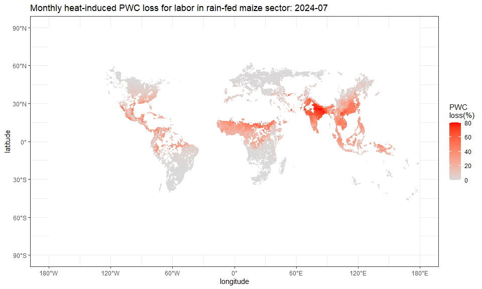

```r
pwc.mon.plot <- pwc.hothaps.mon[[7]] %>% as.data.frame(xy = T)

format_longitude <- function(lon) {
  sapply(lon, function(x) {
    if (x > 0) paste0(x, "°E")
    else if (x < 0) paste0(abs(x), "°W")
    else paste0(x, "°") # Handle 0° specifically
  })
}

format_latitude <- function(lat) {
  sapply(lat, function(x) {
    if (x > 0) paste0(x, "°N")
    else if (x < 0) paste0(abs(x), "°S")
    else paste0(x, "°") # Handle 0° specifically
  })
}
pwc.mon.plot %>%
  setNames(c("x", "y", "value")) %>%
  ggplot() +
  geom_tile(aes(x = x, y = y, fill = 100*(1-value))) +
  scale_fill_gradient(low = "grey85", high = "red",
                      na.value = "white")+
  labs(x = "longitude", y = "latitude", fill = "PWC \nloss(%)",
       title = "Monthly heat-induced PWC loss for labor in rain-fed maize sector: 2024-07") +
  scale_x_continuous(
    breaks = seq(-180, 180, by = 60), # Longitude breaks
    labels = format_longitude         # Apply custom labels
  ) +
  scale_y_continuous(
    breaks = seq(-90, 90, by = 30),    # Latitude breaks
    labels = format_latitude           # Apply custom latitude labels
  ) +
  theme_bw()
```

### Step1.4: aggregate monthly value to annual value

This step employs `MON2ANN()` function, which takes a raster rack with 12 layers of monthly mean as input, and outputs a data frame with grid-level annual mean. In this step, make sure the `SECTOR` input in `MON2ANN()` is identical to the `SECTOR` input in `HeatStress()`

```r
wbgt.sun.ann <- MON2ANN(input_rack = wbgt.sun.mon, SECTOR = "MAIZ_R")
pwc.hothaps.ann <- MON2ANN(input_rack = pwc.hothaps.mon, SECTOR = "MAIZ_R")

summary(wbgt.sun.ann)
```

```
#>        x                 y              value
#>  Min.   :-179.75   Min.   :-89.75   Min.   : 8.87
#>  1st Qu.: -89.88   1st Qu.:-44.88   1st Qu.:19.46
#>  Median :   0.00   Median :  0.00   Median :25.74
#>  Mean   :   0.00   Mean   :  0.00   Mean   :24.41
#>  3rd Qu.:  89.88   3rd Qu.: 44.88   3rd Qu.:29.17
#>  Max.   : 179.75   Max.   : 89.75   Max.   :34.00
#>                                     NA's   :238410
```

```r
summary(pwc.hothaps.ann)
```

```
#>        x                 y              value
#>  Min.   :-179.75   Min.   :-89.75   Min.   :0.29
#>  1st Qu.: -89.88   1st Qu.:-44.88   1st Qu.:0.73
#>  Median :   0.00   Median :  0.00   Median :0.90
#>  Mean   :   0.00   Mean   :  0.00   Mean   :0.85
#>  3rd Qu.:  89.88   3rd Qu.: 44.88   3rd Qu.:0.99
#>  Max.   : 179.75   Max.   : 89.75   Max.   :1.00
#>                                     NA's   :238410
```

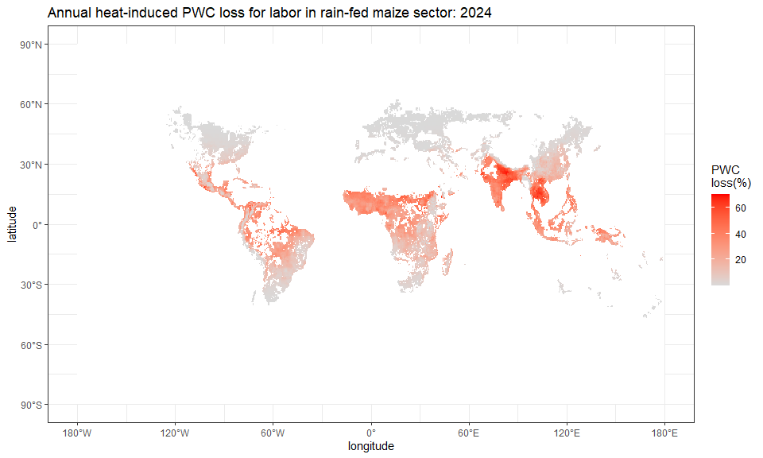

```r
format_longitude <- function(lon) {
  sapply(lon, function(x) {
    if (x > 0) paste0(x, "°E")
    else if (x < 0) paste0(abs(x), "°W")
    else paste0(x, "°") # Handle 0° specifically
  })
}

format_latitude <- function(lat) {
  sapply(lat, function(x) {
    if (x > 0) paste0(x, "°N")
    else if (x < 0) paste0(abs(x), "°S")
    else paste0(x, "°") # Handle 0° specifically
  })
}
pwc.hothaps.ann %>%
  setNames(c("x", "y", "value")) %>%
  ggplot() +
  geom_tile(aes(x = x, y = y, fill = 100*(1-value))) +
  scale_fill_gradient(low = "grey85", high = "red",
                      na.value = "white")+
  labs(x = "longitude", y = "latitude", fill = "PWC \nloss(%)",
       title = "Annual heat-induced PWC loss for labor in rain-fed maize sector: 2024") +
  scale_x_continuous(
    breaks = seq(-180, 180, by = 60), # Longitude breaks
    labels = format_longitude         # Apply custom labels
  ) +
  scale_y_continuous(
    breaks = seq(-90, 90, by = 30),    # Latitude breaks
    labels = format_latitude           # Apply custom latitude labels
  ) +
  theme_bw()
```

## 2. Monthly gridded inputs:

### Step2.1: calculate monthly gridded heat stress

Similar to *Step1.1*, this steps employs`HeatStress()` function. Example below takes monthly *hurs* (relative humidity), *tas* (near-surface air temperature), and *rsds* (surface downwelling shortwave radiation) and *WBGT_ESI* to calculate heat stress levels.

```r
esi.mon <- HeatStress(TempRes = "month", SECTOR = "MAIZ_R", HS = WBGT_ESI, YEAR_INPUT = 2024,
                    "../HELPS_Example_Data/hurs_example_month.nc",
                    "../HELPS_Example_Data/tas_example_month.nc",
                    "../HELPS_Example_Data/rsds_example_month.nc")
esi.mon
```

```
#> class      : RasterStack
#> dimensions : 360, 720, 259200, 12  (nrow, ncol, ncell, nlayers)
#> resolution : 0.5, 0.5  (x, y)
#> extent     : -180, 180, -90, 90  (xmin, xmax, ymin, ymax)
#> crs        : +proj=longlat +datum=WGS84 +no_defs
#> names      : X2024.01.01, X2024.02.01, X2024.03.01, X2024.04.01, X2024.05.01, X2024.06.01, X2024.07.01, X2024.08.01, X2024.09.01, X2024.10.01, X2024.11.01, X2024.12.01
#> min values : -30.0640459, -19.3581926, -11.5180495,  -3.6726991,  -3.2108038,  -0.2240083,  -0.4961621,   0.2276950,   1.7499020,  -5.9289555, -15.8256390, -26.2432665
#> max values :    30.42680,    30.49348,    30.82212,    31.40889,    32.81928,    32.28757,    32.19278,    34.97054,    31.99175,    30.88973,    30.47448,    30.35880
```

Similar to *Step1.2*, this step employs `PWC()` function to translate heat stress to PWC. Here we demonstrate the uncertainty in PWC introduced by alternative choices of `LHR()`.

```r
start_t = Sys.time()
pwc.mon.foster <- PWC(WBGT = esi.mon,  LHR = LHR_Foster, workload = "high")
end_t = Sys.time()
end_t - start_t
```

```
#> Time difference of 22.44854 secs
```

```r
pwc.mon.foster
```

```
#> class      : RasterStack
#> dimensions : 360, 720, 259200, 12  (nrow, ncol, ncell, nlayers)
#> resolution : 0.5, 0.5  (x, y)
#> extent     : -180, 180, -90, 90  (xmin, xmax, ymin, ymax)
#> crs        : +proj=longlat +datum=WGS84 +no_defs
#> names      : X2024.01.01, X2024.02.01, X2024.03.01, X2024.04.01, X2024.05.01, X2024.06.01, X2024.07.01, X2024.08.01, X2024.09.01, X2024.10.01, X2024.11.01, X2024.12.01
#> min values :   0.6533050,   0.6501601,   0.6345732,   0.6064736,   0.5385404,   0.5641103,   0.5686806,   0.4384579,   0.5783792,   0.6313511,   0.6510568,   0.6565059
#> max values :           1,           1,           1,           1,           1,           1,           1,           1,           1,           1,           1,           1
```

```r
start_t = Sys.time()
pwc.mon.hothaps <- PWC(WBGT = esi.mon,  LHR = LHR_Hothaps, workload = "high")
end_t = Sys.time()
end_t - start_t
```

```
#> Time difference of 0.8546791 secs
```

```r
pwc.mon.hothaps
```

```
#> class      : RasterStack
#> dimensions : 360, 720, 259200, 12  (nrow, ncol, ncell, nlayers)
#> resolution : 0.5, 0.5  (x, y)
#> extent     : -180, 180, -90, 90  (xmin, xmax, ymin, ymax)
#> crs        : +proj=longlat +datum=WGS84 +no_defs
#> names      : X2024.01.01, X2024.02.01, X2024.03.01, X2024.04.01, X2024.05.01, X2024.06.01, X2024.07.01, X2024.08.01, X2024.09.01, X2024.10.01, X2024.11.01, X2024.12.01
#> min values :   0.6122206,   0.6041627,   0.5642868,   0.4939780,   0.3453889,   0.3967577,   0.4065680,   0.2037739,   0.4279752,   0.5560881,   0.6064606,   0.6204155
#> max values :           1,           1,           1,           1,           1,           1,           1,           1,           1,           1,           1,           1
```

```r
start_t = Sys.time()
pwc.mon.niosh <- PWC(WBGT = esi.mon,  LHR = LHR_NIOSH, workload = "high")
end_t = Sys.time()
end_t - start_t
```

```
#> Time difference of 30.67523 secs
```

```r
pwc.mon.niosh
```

```
#> class      : RasterStack
#> dimensions : 360, 720, 259200, 12  (nrow, ncol, ncell, nlayers)
#> resolution : 0.5, 0.5  (x, y)
#> extent     : -180, 180, -90, 90  (xmin, xmax, ymin, ymax)
#> crs        : +proj=longlat +datum=WGS84 +no_defs
#> names      : X2024.01.01, X2024.02.01, X2024.03.01, X2024.04.01, X2024.05.01, X2024.06.01, X2024.07.01, X2024.08.01, X2024.09.01, X2024.10.01, X2024.11.01, X2024.12.01
#> min values :  0.40541352,  0.39455391,  0.34102516,  0.24545292,  0.01573185,  0.10233567,  0.11777373,  0.00000000,  0.15051821,  0.33001372,  0.39764806,  0.41648971
#> max values :           1,           1,           1,           1,           1,           1,           1,           1,           1,           1,           1,           1
```

```r
start_t = Sys.time()
pwc.mon.iso <- PWC(WBGT = esi.mon,  LHR = LHR_ISO, workload = "high")
end_t = Sys.time()
end_t - start_t
```

```
#> Time difference of 31.15619 secs
```

```r
pwc.mon.iso
```

```
#> class      : RasterStack
#> dimensions : 360, 720, 259200, 12  (nrow, ncol, ncell, nlayers)
#> resolution : 0.5, 0.5  (x, y)
#> extent     : -180, 180, -90, 90  (xmin, xmax, ymin, ymax)
#> crs        : +proj=longlat +datum=WGS84 +no_defs
#> names      : X2024.01.01, X2024.02.01, X2024.03.01, X2024.04.01, X2024.05.01, X2024.06.01, X2024.07.01, X2024.08.01, X2024.09.01, X2024.10.01, X2024.11.01, X2024.12.01
#> min values :  0.31366421,  0.30282687,  0.24940794,  0.15403177,  0.00000000,  0.01120813,  0.02661452,  0.00000000,  0.05929182,  0.23841909,  0.30591467,  0.32471767
#> max values :           1,           1,           1,           1,           1,           1,           1,           1,           1,           1,           1,           1
```

### Step2.3: aggregate monthly value to annual value

Same as *Step1.4*, make sure the `SECTOR` input in `MON2ANN()` is identical to the `SECTOR` input in `HeatStress()`.

```r
pwc.hothaps.ann2 <- MON2ANN(input_rack = pwc.mon.hothaps, SECTOR = "MAIZ_R")
summary(pwc.hothaps.ann2)
```

```
#>        x                 y              value
#>  Min.   :-179.75   Min.   :-89.75   Min.   :0.45
#>  1st Qu.: -89.88   1st Qu.:-44.88   1st Qu.:0.95
#>  Median :   0.00   Median :  0.00   Median :0.99
#>  Mean   :   0.00   Mean   :  0.00   Mean   :0.97
#>  3rd Qu.:  89.88   3rd Qu.: 44.88   3rd Qu.:1.00
#>  Max.   : 179.75   Max.   : 89.75   Max.   :1.00
#>                                     NA's   :238410
```

## 3. Spatial aggregation: grid to region

### Step3.1: aggregate grid-level values to country-level values

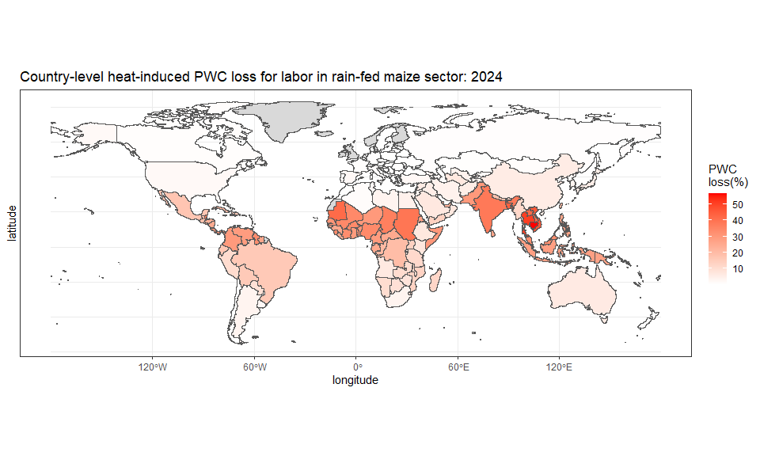

```r
GCAM_country %>% left_join(ctry_pwc, by = "ctry_id") %>%
  ggplot() +
  geom_sf(aes(fill = 100 * (1-PWC))) +
  scale_fill_gradient(low = "white", high = "red",
                      na.value = "grey85")+
  labs(x = "longitude", y = "latitude", fill = "PWC \nloss(%)",
       title = "Country-level heat-induced PWC loss for labor in rain-fed maize sector: 2024") +
  theme_bw()
```

### Step3.2: aggregate grid-level values to GCAM waterbasin level values

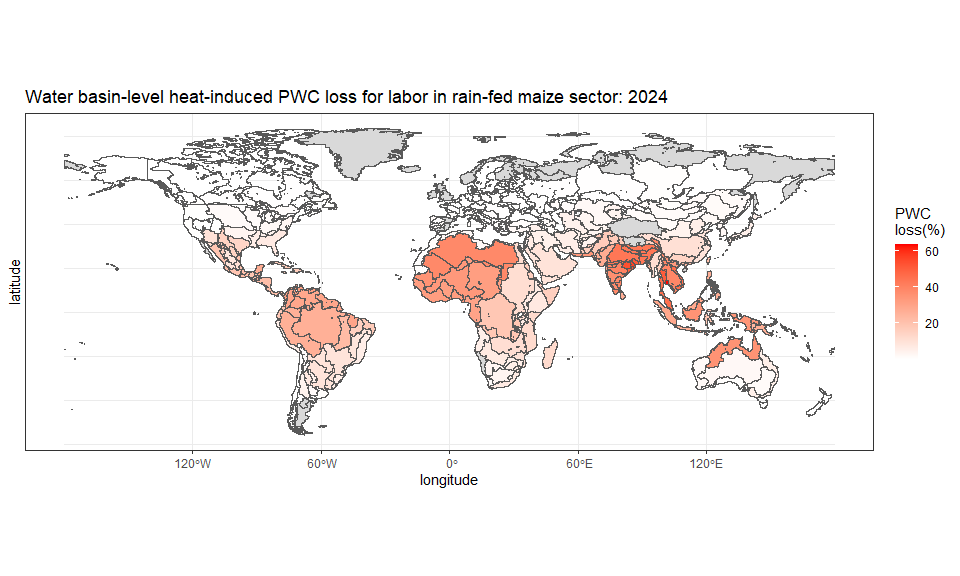

```r
reg_WB %>% left_join(glu_pwc, by = "glu_id") %>%
  ggplot() +
  geom_sf(aes(fill = 100 * (1-PWC))) +
  scale_fill_gradient(low = "white", high = "red",
                      na.value = "grey85")+
  labs(x = "longitude", y = "latitude", fill = "PWC \nloss(%)",
       title = "Water basin-level heat-induced PWC loss for labor in rain-fed maize sector: 2024") +
  theme_bw()
```